# Project: Investigating why patients don't show up at the appointments?

### What is the gender distribution in patients?

```python
# categorising the gender in male and female

male = df.query('gender == "M"')
female = df.query('gender == "F"')
```

```python
# counting number of patients in each category

count_male = male['gender'].count()
count_female = female['gender'].count()
```

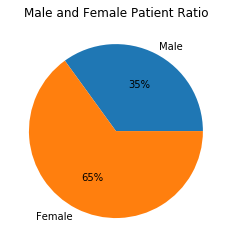

```python
# visualizing gender distribution

sizes = [count_male, count_female]
label = ['Male', 'Female']
plt.pie(sizes, labels = label, autopct='%1.0f%%');
plt.title("Male and Female Patient Ratio");
```

### What is the age distribution in patients?

```python
# categorising the age in 4 sections

below_25 = df.query('age < 25')
between_25_50 = df.query('age < 50 and age >= 25')
between_50_75 = df.query('age < 75 and age >= 50')
above_75 = df.query('age >= 75')
```

```python
# counting number of patients in each category

count_below_25 = below_25['age'].count()
count_between_25_50 = between_25_50['age'].count()
count_between_50_75 = between_50_75['age'].count()
count_above_75 = above_75['age'].count()
```

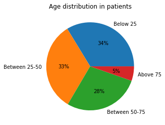

```python
# visualizing age distribution

sizes = [count_below_25, count_between_25_50, count_between_50_75, count_above_75]
label = ['Below 25', 'Between 25-50', 'Between 50-75', 'Above 75']
plt.pie(sizes, labels = label, autopct='%1.0f%%');
plt.title("Age distribution in patients");
```

```python
# calculating proportion for better insights

total_patients = df['age'].count()

prop_below_25 = count_below_25 / total_patients
prop_between_25_50 = count_between_25_50 / total_patients
prop_between_50_75 = count_between_50_75 / total_patients
prop_above_75 = count_above_75 / total_patients
```

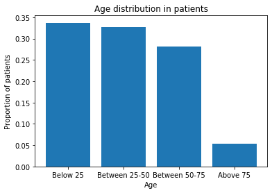

```python
#plotting the age distribution graph

locations = [1, 2, 3, 4]
height = [prop_below_25, prop_between_25_50, prop_between_50_75, prop_above_75]
labels = ['Below 25', 'Between 25-50', 'Between 50-75', 'Above 75']
plt.bar(locations, height, tick_label=labels)
plt.title('Age distribution in patients')
plt.xlabel('Age')
plt.ylabel('Proportion of patients')
plt.show()
```

> **Insights**:
> 1. Most of the patients are below 75 years of age, only around 5% patients are older than that.
> 2. 34% patients are below 25.
> 3. 33% patients are beween the age of 25 to 50.
> 4. 28% belong to the Between 50-75 category.

### Which age groups are more likely to not show up at the appointment?

```python
# calculating sum of noshow in different categories of ages

count_below_25_noshow = below_25['noshow'].sum()
count_between_25_50_noshow = between_25_50['noshow'].sum()
count_between_50_75_noshow = between_50_75['noshow'].sum()
count_above_75_noshow = above_75['noshow'].sum()
```

```python
# calculating proportion for better insights

prop_below_25_noshow = count_below_25_noshow / count_below_25
prop_between_25_50_noshow = count_between_25_50_noshow / count_between_25_50
prop_between_50_75_noshow = count_between_50_75_noshow / count_between_50_75
prop_above_75_noshow = count_above_75_noshow / count_above_75
```

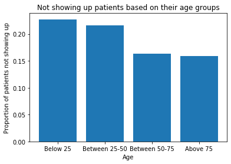

```python
# plotting the proportion of not showing up patients on the basis of age category

locations = [1, 2, 3, 4]
height = [prop_below_25_noshow, prop_between_25_50_noshow, prop_between_50_75_noshow, prop_above_75_noshow]
labels = ['Below 25', 'Between 25-50', 'Between 50-75', 'Above 75']
plt.bar(locations, height, tick_label=labels)
plt.title('Not showing up patients based on their age groups')
plt.xlabel('Age')
plt.ylabel('Proportion of patients not showing up')
plt.show()
```

> **Insights**:
> 1. Around 23% patients in the Below 25 category don't show up at the appointment.
> 2. Around 22% patients in the Between 25-50 category don't show up at the appointment.
> 3. Around 15% patients in the Between 50-75 category don't show up at the appointment.
> 4. Around 15% patients in the Above 75 category don't show up at the appointment.

### Which specific condition or combination of specific conditions are related to no show up?

```python
# number of not showing up patients based on their different specific condition condition

specific_con_noshow = df.groupby(['hypertension', 'diabetes', 'alcoholism', 'handicapped'])['noshow'].sum()
specific_con_noshow
```

```
hypertension  diabetes  alcoholism  handicapped
0             0         0           0              17603
                                    1                219
                        1           0                416
                                    1                  3
              1         0           0                273
                                    1                  3
                        1           0                 12
                                    1                  1
1             0         0           0               2325
                                    1                 92
                        1           0                197
                                    1                  1
              1         0           0               1044
                                    1                 44
                        1           0                 42
                                    1                  3
Name: noshow, dtype: int64
```

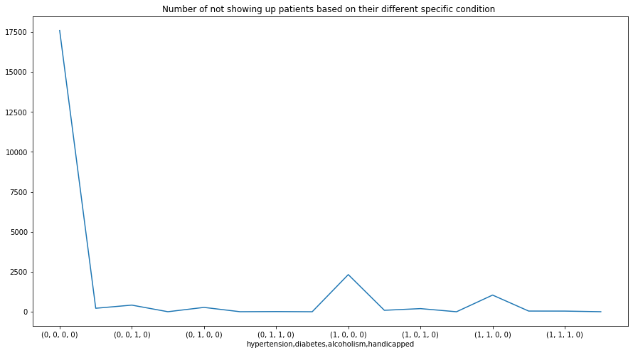

```python
# plotting a graph demonstrating the number of not showing up patients based on their different specific condition
specific_con_noshow.plot(x = 'Number of patients', y = 'Specific condition', figsize=(15,8), title = 'Number of not showing up patients based on their different specific condition ');
```

> **Insights**:
> 1. Most of the patients who do not have any specific condition they are not showing up at the appointment.
> 2. There are also a significant number of patients who have hypertention and they are not showing up at the appointment.

### Relationship of various factors(scholarship, hypertension,diabetes, alcoholism, handicap, smsreceived) with noshow

```python
# finding the count of patients on various factors

noshow_factors = df.groupby('noshow')['hypertension', 'diabetes', 'alcoholism', 'handicapped'].sum()
noshow_factors
```

| noshow | hypertension | diabetes | alcoholism | handicapped |
| --- | --- | --- | --- | --- |
| 0 | 17968 | 6478 | 2677 | 1676 |
| 1 | 3748 | 1422 | 675 | 366 |

```python
# pateints who don't show up on various factors

noshow_yes_factors = noshow_factors.query("noshow == 1")
noshow_yes_factors
```

| noshow | hypertension | diabetes | alcoholism | handicapped |
| --- | --- | --- | --- | --- |
| 1 | 3748 | 1422 | 675 | 366 |

```python
# calculating total not showing up patients

noshow_yes_total = df['noshow'].value_counts()[1]
```

```python
# make proportions for each elements to find the relationships

prop_noshow_yes_factors = noshow_yes_factors / noshow_yes_total
prop_noshow_yes_factors
```

| noshow | hypertension | diabetes | alcoholism | handicapped |
| --- | --- | --- | --- | --- |
| 1 | 0.168238 | 0.06383 | 0.030299 | 0.016429 |

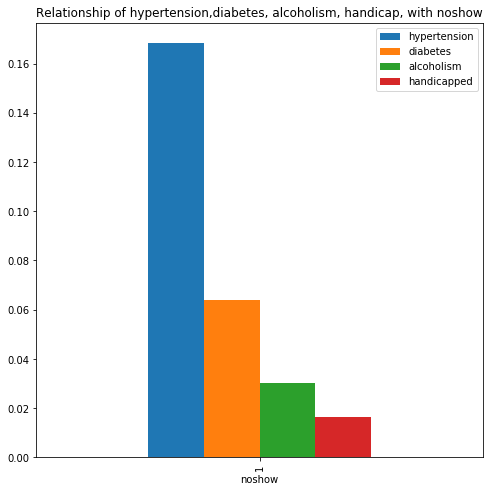

```python
# plotting the relationship

#sns.set_style('darkgrid')
prop_noshow_yes_factors.plot(kind='bar',figsize=(8,8), title='Relationship of hypertension,diabetes, alcoholism, handicap, with noshow')
```

### What is the relationship between hypertension and diabetes

```python
# patients having hypertension but checking whether they have diabetes or not

hyp_dia =  df.query('hypertension == 1')['diabetes'].value_counts()
hyp_dia
```

```
0    15272
1     6444
Name: diabetes, dtype: int64
```

```python
# calculating proportions for better insights

total = hyp_dia.sum()
prop_hyp_dia = hyp_dia/ total
prop_hyp_dia
```

```
0    0.70326
1    0.29674
Name: diabetes, dtype: float64
```

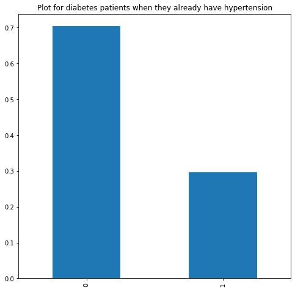

```python
# plot for diabetes patients when they already have hypertension

prop_hyp_dia.plot(kind = 'bar', figsize=(8,8), title='Plot for diabetes patients when they already have hypertension')
```

### What is the relationship between no show up and the scholarship received?

```python
# separating patients who receive scholarship and who don't

scholarship = df.query('scholarship == 1')
no_scholarship = df.query('scholarship == 0')
```

```python
# number of not showing up patients based whether the scholarship is provided or not

count_scholarship_noshow = scholarship['noshow'].sum()
count_no_scholarship_noshow = no_scholarship['noshow'].sum()
```

```python
# calculating proportion for better insights

prop_scholarship_noshow = count_scholarship_noshow / scholarship['noshow'].count()
prop_no_scholarship_noshow = count_no_scholarship_noshow / no_scholarship['noshow'].count()
```

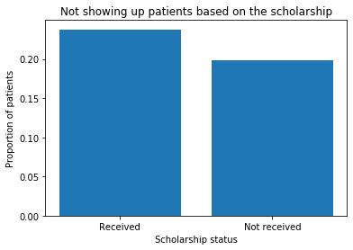

```python
# plotting the propotion of not showing up patients based on the scholarship

locations = [1, 2]
height = [prop_scholarship_noshow, prop_no_scholarship_noshow]
labels = ['Received', 'Not received']
plt.bar(locations, height, tick_label=labels)
plt.title('Not showing up patients based on the scholarship')
plt.xlabel('Scholarship status')
plt.ylabel('Proportion of patients')
plt.show()
```

### How is not showing up of the patients is related to their sms receiving?

```python
# separating patients who receive sms and who don't

smsreceived = df.query('smsreceived == 1')
no_smsreceived = df.query('smsreceived == 0')
```

```python
# number of not showing up patients based on whether they receive sms or not

count_smsreceived_noshow = smsreceived['noshow'].sum()
count_no_smsreceived_noshow = no_smsreceived['noshow'].sum()
```

```python
# calculating proportion for better insights

prop_smsreceived_noshow = count_smsreceived_noshow / smsreceived['noshow'].count()
prop_no_smsreceived_noshow = count_no_smsreceived_noshow / no_smsreceived['noshow'].count()
```

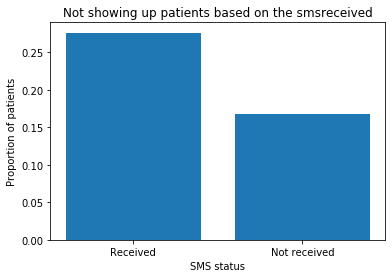

```python
# plotting the propotion of not showing up patients based on smsreceived

locations = [1, 2]
height = [prop_smsreceived_noshow, prop_no_smsreceived_noshow]
labels = ['Received', 'Not received']
plt.bar(locations, height, tick_label=labels)
plt.title('Not showing up patients based on the smsreceived')
plt.xlabel('SMS status')
plt.ylabel('Proportion of patients')
plt.show()
```

## Conclusions

> **Note**: Statistical tests are not conducted in this analysis, so the findings are only tentative.